# **Proyecto Final: Predicción del Riesgo de Enfermedades Cardíacas mediante Regresión Logística**

Autores:** Jesus David Arevalo, Juan Sebastian Quintana

# **Introducción:**

## **Contextualización:**

Las enfermedades cardíacas figuran entre las afecciones crónicas más prevalentes en los Estados Unidos, afectando a millones de estadounidenses cada año, con implicaciones significativas tanto para la salud individual como para la economía nacional. En los Estados Unidos, estas enfermedades se sitúan como una de las principales causas de muerte, con aproximadamente 647,000 personas falleciendo por estas afecciones anualmente. La compleja interacción entre variables como el envejecimiento, la hipertensión y la diabetes contribuye como factores de riesgo y causas de enfermedades cardíacas.

## **Contenido:**

El Sistema de Vigilancia de Factores de Riesgo Conductuales (BRFSS, por sus siglas en inglés) es una encuesta telefónica sobre la salud que se recopila anualmente por los Centros para el Control y la Prevención de Enfermedades (CDC). Cada año, la encuesta recopila respuestas de más de 400,000 estadounidenses sobre comportamientos relacionados con la salud, condiciones de salud crónicas y el uso de servicios preventivos. Esta encuesta se realiza anualmente desde 1984. Para este proyecto, descargué un archivo CSV del conjunto de datos disponible en Kaggle correspondiente al año 2015. Este conjunto de datos original contiene respuestas de 441,455 individuos y comprende 330 características. Estas características incluyen preguntas directamente formuladas a los participantes o variables calculadas basadas en las respuestas individuales de los participantes.

Este conjunto de datos depurado contiene 253,680 respuestas de la encuesta BRFSS 2015, utilizado principalmente para la clasificación binaria de enfermedades cardíacas. Es relevante señalar que existe un fuerte desequilibrio de clases en este conjunto de datos: 229,787 encuestados no tienen o no han tenido enfermedad cardíaca, mientras que 23,893 han tenido enfermedad cardíaca.

Se estudiarán diversas variables relacionadas con enfermedades cardíacas en el contexto de un modelo de regresión logística. Estas variables incluyen la presión arterial alta (**HighBP**), el colesterol alto (**HighChol**), el índice de masa corporal (**BMI**), el hábito de fumar (**Smoker**), la ocurrencia de accidentes cerebrovasculares (**Stroke**), la presencia de diabetes (**Diabetes**), la actividad física (**PhysActivity**), el consumo de frutas (**Fruits**), el consumo de verduras (**Veggies**) y el consumo intenso de alcohol (**HvyAlcoholConsump**). Además, se explorarán factores socioeconómicos como la educación (**Education**) y los ingresos (**Income**), junto con variables demográficas como el género (**Sex**) y la edad (**Age**).

## **Relevancia del trabajo:**

Este trabajo reconoce el impacto que esta enfermedad tiene en la tasa de mortalidad de los habitantes de los Estados Unidos y, más allá, el peso financiero generado. A partir de esto, surge la iniciativa de desarrollar diversas estrategias de prevención efectivas y precisas. El hecho de que las personas tiendan a descubrir que padecen alguna enfermedad cardíaca después de experimentar los primeros síntomas o, en casos extremos, después de un episodio que requirió intervención médica, como un paro cardíaco, respalda la urgencia de implementar medidas de intervención proactivas para evitar los desenlaces más graves. **Esto construirá una cultura de cuidado y prevención en torno a esta enfermedad, desde el profesional de la salud hasta el individuo.**

Identificar los factores de riesgo es fundamental para los Centros de Control y Prevención. De manera alarmante, aproximadamente la mitad de los estadounidenses presenta al menos uno de estos factores de riesgo. El Instituto Nacional del Corazón, Pulmón y Sangre destaca una gama más amplia de consideraciones diagnósticas, que abarcan la edad, el entorno, antecedentes familiares, genética, hábitos de vida, otras condiciones médicas, raza o etnia, y género. Estos factores constituyen la base para encuestas iniciales y pruebas diagnósticas posteriores.

El diagnóstico de una enfermedad cardíaca debe tener un enfoque integral, no basarse solo en las causas tradicionales, sino también considerar el panorama de la salud individual. Por lo tanto, herramientas como encuestas y pruebas diagnósticas, acompañadas de muestras de sangre, amplían la detección de factores de riesgo a un nivel más único para cada paciente, permitiendo una gestión efectiva de la enfermedad.

Abordar esta problemática desde el enfoque de la prevención es altamente relevante, como se ha observado en los párrafos anteriores. Además de la carga emocional y física para los individuos afectados, también representa un enorme desafío económico para el sistema de atención médica y para la sociedad en general. El costo asociado con el tratamiento de enfermedades cardíacas, incluyendo hospitalizaciones, procedimientos médicos y medicamentos, contribuye significativamente a los gastos totales en salud. La importancia de la prevención radica en la capacidad de mitigar estos costos, mejorar la calidad de vida de los individuos y, lo más crucial, salvar vidas. **Las estrategias preventivas pueden abordar no solo los factores de riesgo conocidos, sino también educar y empoderar a la población para tomar decisiones saludables en su vida diaria.**

## **Objetivos:**

En este trabajo, el objetivo principal es predecir de manera asertiva y eficiente el riesgo que una persona tiene de padecer una enfermedad cardíaca. También se tiene en cuenta la relación entre las variables actuales del conjunto de datos extraído, con el fin de explicar y entender los resultados a nivel predictivo. Es importante considerar que puede haber variables igualmente relevantes que no fueron incluidas en esta encuesta, de la cual se tomaron los datos.

# **Dataset:**

```
## # A tibble: 5 × 15
##   HeartDiseaseorAttack HighBP HighChol   BMI Smoker Stroke Diabetes PhysActivity
##                  <dbl>  <dbl>    <dbl> <dbl>  <dbl>  <dbl>    <dbl>        <dbl>
## 1                    0      1        1    40      1      0        0            0
## 2                    0      0        0    25      1      0        0            1
## 3                    0      1        1    28      0      0        0            0
## 4                    0      1        0    27      0      0        0            1
## 5                    0      1        1    24      0      0        0            1
## # ℹ 7 more variables: Fruits <dbl>, Veggies <dbl>, HvyAlcoholConsump <dbl>,
## #   Sex <dbl>, Age <dbl>, Education <dbl>, Income <dbl>
```

Previo a continuar con la exploracion de los datos se substraen 7 variables que en la teoria o por la forma en la que fueron evaluadas no presentan una relacion directa con nuestra variable independiente: **HeartDiseaseorAttack**, los nombres de las columnas extraidas fueron: CholCheck, AnyHealthcare, NoDocbcCost, GenHlth, MentHlth, MentHlth, DiffWalk.

# **Exploratorio:**

## **Descriptivo de las variables numericas del dataset:**

### **Resúmenes de Age y BMI con Desviaciones Estándar:**

|  | Min. | 1st Qu. | Median | Mean | 3rd Qu. | Max. | SD |
| --- | --- | --- | --- | --- | --- | --- | --- |
| **Age** | 1 | 6 | 8 | 8.065843 | 10 | 13 | 3.100976 |
| **BMI** | 12 | 24 | 27 | 27.848765 | 31 | 96 | 6.101022 |

### **Boxplot de las variables Edad y BMI:**

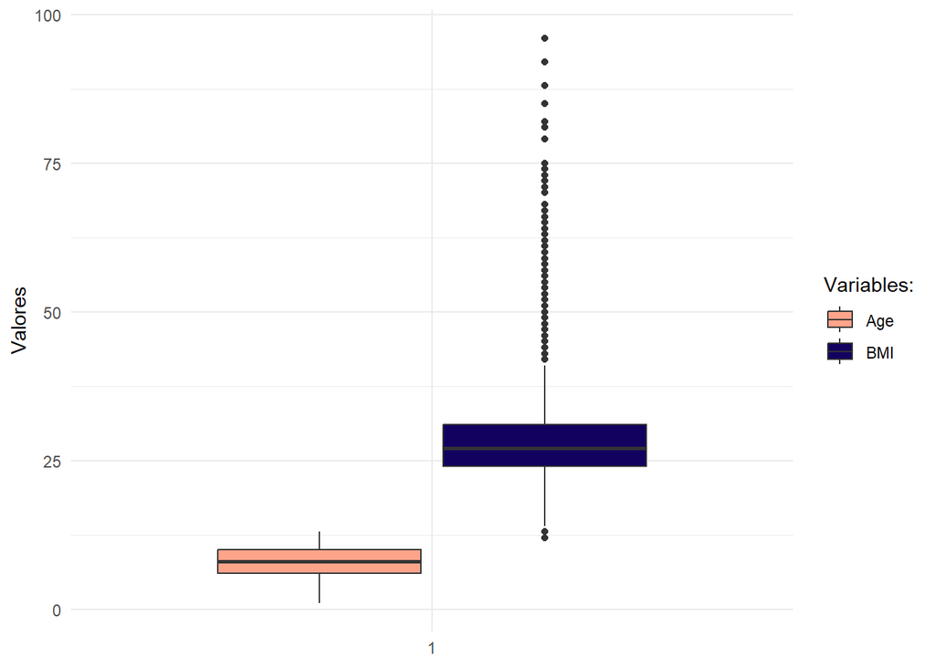

### **Histogramas de las variables Age y BMI:**

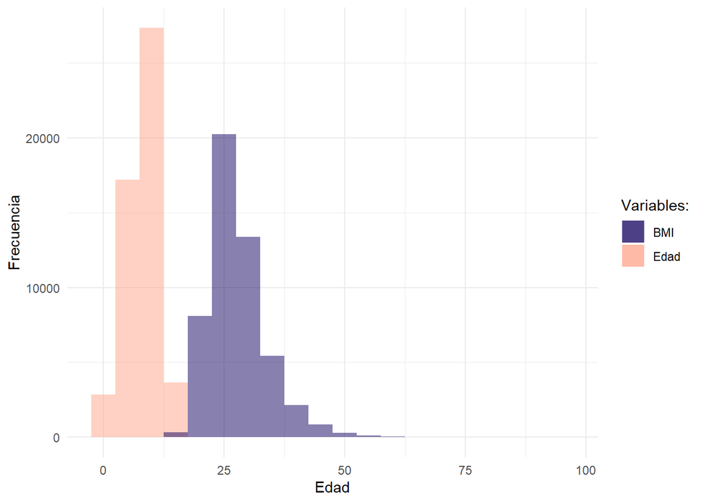

```r
#barplot()
```

# Modelo Completo:

```r
modelo <- glm(HeartDiseaseorAttack~BMI+Age+HighBP+HighChol+Smoker+Stroke+Diabetes+PhysActivity+Fruits+Veggies+Education+Income+Sex, family=binomial(link = "logit"), data=df)
summary(modelo)
```

```
##
## Call:
## glm(formula = HeartDiseaseorAttack ~ BMI + Age + HighBP + HighChol +
##     Smoker + Stroke + Diabetes + PhysActivity + Fruits + Veggies +
##     Education + Income + Sex, family = binomial(link = "logit"),
##     data = df)
##
## Coefficients:
##               Estimate Std. Error z value Pr(>|z|)
## (Intercept)  -5.583867   0.153060 -36.482  < 2e-16 ***
## BMI           0.016322   0.002839   5.749 8.97e-09 ***
## Age           0.235853   0.007616  30.969  < 2e-16 ***
## HighBP        0.683223   0.039672  17.222  < 2e-16 ***
## HighChol      0.636609   0.036404  17.487  < 2e-16 ***
## Smoker        0.398292   0.034664  11.490  < 2e-16 ***
## Stroke        1.306497   0.052352  24.956  < 2e-16 ***
## Diabetes      0.218375   0.020014  10.911  < 2e-16 ***
## PhysActivity -0.200393   0.037892  -5.289 1.23e-07 ***
## Fruits       -0.028662   0.036347  -0.789    0.430
## Veggies       0.059537   0.043246   1.377    0.169
## Education    -0.007291   0.018145  -0.402    0.688
## Income       -0.125547   0.008871 -14.153  < 2e-16 ***
## Sex           0.688308   0.035318  19.489  < 2e-16 ***
## ---
## Signif. codes:  0 '***' 0.001 '**' 0.01 '*' 0.05 '.' 0.1 ' ' 1
##
## (Dispersion parameter for binomial family taken to be 1)
##
##     Null deviance: 30785  on 50999  degrees of freedom
## Residual deviance: 24808  on 50986  degrees of freedom
## AIC: 24836
##
## Number of Fisher Scoring iterations: 6
```

```r
coefficients(modelo)
```

```
##  (Intercept)          BMI          Age       HighBP     HighChol       Smoker
## -5.583867380  0.016322254  0.235853318  0.683222994  0.636609195  0.398292296
##       Stroke     Diabetes PhysActivity       Fruits      Veggies    Education
##  1.306497121  0.218374948 -0.200392706 -0.028662285  0.059536744 -0.007290946
##       Income          Sex
## -0.125546520  0.688307700
```